# Prepare structured (SABAP2) and unstructured data for the Western Cape

Katelyn Faulkner

2025-04-15

```r
# Load packages
library(tidyverse) # Data wrangling and visualisation
library(here)      # Relative paths
library(sf)        # Work with spatial data
library(rgbif)     # To request occurrence cubes
```

# Goal

Load and save structured data from the Western Cape of the “Southern African Bird Atlas Project 2” (SABAP2).

Load and save unstructured data from GBIF.

SABAP2 data are collected at a pentad resolution (5min x 5min).

The data are prepared both at a pentad resolution, and at quarter degree grid cell resolution (QDGC). 9 pentads fit into one quarter degree grid cell (15 min x 15 min)

The period 2008-2024 is of interest

# Load data

## Structured data

### Sampling framework

**Western Cape SABAP2 - Southern African Bird Atlas Project 2 - sampling framework for Western Cape** is downloaded as a geoJSON file from https://sabap2.birdmap.africa/coverage/province/westerncape.

Follow the instructions on the website to download the file, then save it as a shapefile and store under *./data/raw*.

We read in the dataset.

```r
# Data path and create directory if necessary
data_path <- here::here("data", "raw")
dir.create(data_path, showWarnings = FALSE, recursive = TRUE)
```

```r
# Read SABAP2 Western Cape pentad grid (5min x 5 min/ 8.2 km x 8.2 km)
WCSFraw <- read_sf(file.path(data_path, "WesternCape_sampling_framework", "WesternCape_sampling_framework.shp"))

# Explore dataframe
glimpse(WCSFraw)
```

```
## Rows: 1,842
## Columns: 27
## $ pentad       <chr> "3025_1830", "3030_1830", "3030_1835", "3035_1825", "3035…
## $ `full proto` <dbl> 2, 3, 2, 2, 3, 7, 20, 2, 4, 2, 4, 5, 2, 8, 2, 3, 1, 4, 2,…
## $ `full pro_1` <dbl> 8, 8, 4, 4, 14, 23, 62, 4, 8, 4, 8, 13, 3, 39, 4, 7, 2, 9…
## $ `adhoc prot` <dbl> 0, 1, 0, 0, 0, 0, 13, 1, 1, 2, 1, 9, 10, 2, 5, 1, 1, 1, 2…
## $ incidental   <dbl> 0, 0, 0, 0, 0, 0, 0, 0, 0, 0, 0, 0, 0, 0, 0, 0, 0, 0, 0, …
## $ additional   <dbl> 0, 0, 0, 0, 0, 0, 0, 0, 0, 0, 0, 0, 0, 0, 0, 0, 0, 0, 0, …
## $ `2007`       <dbl> 0, 0, 0, 0, 0, 0, 0, 0, 0, 0, 0, 0, 0, 0, 0, 0, 0, 0, 0, …
## $ `2008`       <dbl> 0, 0, 0, 0, 0, 0, 0, 0, 0, 0, 0, 0, 0, 0, 0, 0, 0, 0, 0, …
## $ `2009`       <dbl> 0, 0, 0, 0, 0, 0, 0, 0, 0, 0, 0, 0, 0, 0, 0, 0, 0, 0, 0, …
## $ `2010`       <dbl> 0, 0, 0, 0, 1, 0, 1, 0, 0, 0, 0, 0, 0, 0, 0, 0, 0, 0, 0, …
## $ `2011`       <dbl> 0, 1, 1, 1, 0, 1, 1, 0, 2, 0, 1, 1, 1, 1, 1, 1, 0, 1, 1, …
## $ `2012`       <dbl> 0, 0, 0, 0, 1, 2, 1, 1, 1, 0, 0, 0, 0, 0, 0, 1, 1, 0, 1, …
## $ `2013`       <dbl> 2, 1, 1, 1, 0, 2, 2, 0, 1, 0, 0, 0, 0, 0, 0, 0, 0, 0, 0, …
## $ `2014`       <dbl> 0, 0, 0, 0, 0, 0, 1, 0, 0, 0, 0, 0, 0, 0, 0, 0, 0, 0, 0, …
## $ `2015`       <dbl> 0, 0, 0, 0, 0, 1, 2, 0, 0, 0, 0, 0, 0, 0, 0, 0, 0, 0, 0, …
## $ `2016`       <dbl> 0, 1, 0, 0, 0, 0, 1, 1, 0, 2, 3, 1, 0, 0, 1, 0, 0, 0, 0, …
## $ `2017`       <dbl> 0, 0, 0, 0, 0, 0, 0, 0, 0, 0, 0, 1, 1, 0, 0, 0, 0, 1, 0, …
## $ `2018`       <dbl> 0, 0, 0, 0, 0, 0, 0, 0, 0, 0, 0, 1, 0, 0, 0, 0, 0, 0, 0, …
## $ `2019`       <dbl> 0, 0, 0, 0, 0, 0, 2, 0, 0, 0, 0, 0, 0, 0, 0, 0, 0, 0, 0, …
## $ `2020`       <dbl> 0, 0, 0, 0, 0, 0, 2, 0, 0, 0, 0, 0, 0, 2, 0, 0, 0, 0, 0, …
## $ `2021`       <dbl> 0, 0, 0, 0, 0, 0, 2, 0, 0, 0, 0, 0, 0, 0, 0, 0, 0, 0, 0, …
## $ `2022`       <dbl> 0, 0, 0, 0, 0, 0, 3, 0, 0, 0, 0, 1, 0, 0, 0, 0, 0, 0, 0, …
## $ `2023`       <dbl> 0, 0, 0, 0, 1, 1, 2, 0, 0, 0, 0, 0, 0, 0, 0, 0, 0, 2, 0, …
## $ `2024`       <dbl> 0, 0, 0, 0, 0, 0, 0, 0, 0, 0, 0, 0, 0, 5, 0, 1, 0, 0, 0, …
## $ `2025`       <dbl> 0, 0, 0, 0, 0, 0, 0, 0, 0, 0, 0, 0, 0, 0, 0, 0, 0, 0, 0, …
## $ format       <chr> "geoJSON", "geoJSON", "geoJSON", "geoJSON", "geoJSON", "g…
## $ geometry     <POLYGON [°]> POLYGON ((18.5 -30.41667, 1..., POLYGON ((18.5 -3…
```

### Occurrence data

Occurrence data was downloaded from GBIF.org. Unzip and store folders under *./data/raw*. The SABAP2 dataset was filtered so that only data from the Western Cape (Administrative areas = Western Cape - ZAF.9_1) was downloaded.

Note these data were not obtained as a cube through rgbif, as some manipulation is required to remove adhoc records that is not possible with the filters available.

GBIF.org (17 January 2025) GBIF Occurrence Download https://doi.org/10.15468/dl.95kujb

We read in the dataset.

```r
# Read SABAP2 data as tab delimited
SABAP2WCraw <- read_delim(file.path(data_path,
                                     "0073671-241126133413365",
                                     "occurrence.txt"),
                   delim = "\t",
                   show_col_types = FALSE)

# Explore dataframe
glimpse(SABAP2WCraw)
```

```
## Rows: 2,500,161
## Columns: 223
## $ gbifID                              <dbl> 2348240488, 2348245274, 2348247726…
## $ accessRights                        <lgl> NA, NA, NA, NA, NA, NA, NA, NA, NA…
## $ bibliographicCitation               <lgl> NA, NA, NA, NA, NA, NA, NA, NA, NA…
## $ language                            <lgl> NA, NA, NA, NA, NA, NA, NA, NA, NA…
## $ license                             <chr> "CC_BY_4_0", "CC_BY_4_0", "CC_BY_4…
## $ modified                            <lgl> NA, NA, NA, NA, NA, NA, NA, NA, NA…
## $ publisher                           <chr> "FitzPatrick Institute of African …
## $ references                          <lgl> NA, NA, NA, NA, NA, NA, NA, NA, NA…
## $ rightsHolder                        <lgl> NA, NA, NA, NA, NA, NA, NA, NA, NA…
## $ type                                <lgl> NA, NA, NA, NA, NA, NA, NA, NA, NA…
## $ institutionID                       <chr> "FIAO", "FIAO", "FIAO", "FIAO", "F…
## $ collectionID                        <chr> "SABAP2", "SABAP2", "SABAP2", "SAB…
## $ datasetID                           <lgl> NA, NA, NA, NA, NA, NA, NA, NA, NA…
```

[output cut: 210 more lines]

## Unstructured data

### Download cube (qdgc per year)

Retrieved the species occurrence cube using rgbif. The occurrence cube is at a QDGC scale per year. To account for sampling bias, the specification recommends including an occurrence count for a higher taxon, typically the family.

The query excluded SABAP2 data

Data for the Western Cape were selected (level1Gid = ‘ZAF.9_1’)

Note personal details (usernname, password and email address) have been removed from script below

```r
# yearly cube at qdgc resolution
occ_download_sql(user = "", pwd = "", email = "",
                 "SELECT \"year\",
                 GBIF_EQDGCCode(2, decimalLatitude, decimalLongitude, COALESCE(coordinateUncertaintyInMeters, 1000)) AS qdgcCode,
                 speciesKey,
                 species,
                 family,
                 COUNT(*) AS n,
                 MIN(COALESCE(coordinateUncertaintyInMeters, 1000)) AS minCoordinateUncertaintyInMeters, IF(ISNULL(family), NULL, SUM(COUNT(*)) OVER (PARTITION BY family)) AS familyCount FROM occurrence WHERE class = 'Aves' AND occurrenceStatus = 'PRESENT' AND NOT ARRAY_CONTAINS(issue, 'ZERO_COORDINATE') AND NOT ARRAY_CONTAINS(issue, 'COORDINATE_OUT_OF_RANGE') AND NOT ARRAY_CONTAINS(issue, 'COORDINATE_INVALID') AND NOT ARRAY_CONTAINS(issue, 'COUNTRY_COORDINATE_MISMATCH') AND level1Gid = 'ZAF.9_1' AND speciesKey IS NOT NULL AND decimalLatitude IS NOT NULL AND decimalLongitude IS NOT NULL AND collectionCode != 'SABAP2'
GROUP BY
\"year\",
qdgcCode,
speciesKey,
family,
species ORDER BY
\"year\" ASC,
qdgcCode ASC,
speciesKey ASC")
```

The data are downloaded and stored under *./data/raw*.

**Unstructured bird data Western Cape QGDC cube**: 0002739-250121130708018.zip

GBIF.org (23 January 2025) GBIF Occurrence Download https://doi.org/10.15468/dl.pc226a

We read in the dataset.

```r
# Read in datacube from CSV
birdcubeWCYearQDGC <- read_delim(file.path(data_path,
                                     "0002739-250121130708018", "0002739-250121130708018.csv"),
                   delim = "\t",
                   show_col_types = FALSE)

# Explore dataframe
glimpse(birdcubeWCYearQDGC)
```

```
## Rows: 381,658
## Columns: 8
## $ year                             <dbl> NA, NA, NA, NA, NA, NA, NA, NA, NA, N…
## $ qdgccode                         <chr> "E017S32BB", "E017S32DB", "E017S32DB"…
## $ specieskey                       <dbl> 2494088, 2481173, 2481890, 5229384, 2…
## $ species                          <chr> "Euplectes orix", "Larus dominicanus"…
## $ family                           <chr> "Ploceidae", "Laridae", "Phalacrocora…
## $ n                                <dbl> 1, 1, 1, 1, 1, 1, 1, 1, 1, 2, 1, 1, 1…
## $ mincoordinateuncertaintyinmeters <dbl> 111111, 1000, 1000, 1000, 1000, 1000,…
## $ familycount                      <dbl> 140960, 119336, 78437, 7542, 119336, …
```

### Download occurrence data and create cube (pentad per year)

Cube at pentad resolution not available through rgbif. Therefore, downloaded occurrence data, and created a yearly cube at pentad resolution.

Note for Hessequa Atlas area this was done using gcube. This is not possible at the moment, as gcube can only be used to create cubes for grids on a flat co-ordinate system, and there isn’t one that covers the whole of the Western Cape. gcube will be used in future when it is possible. Thus for now assumed a record is in a grid cell in which it falls, no matter the uncertainty.

Occurrence data is downloaded from GBIF.org. Unzip and store folder under *./data/raw*.

Filters were:

Occurrence status = Present

Class = Aves

Year = Between 2008 and 2024

Administrative areas (gadm) = Western Cape - ZAF.9_1

Location: Including co-ordinates

Excluded SABAP2 dataset

GBIF.org (28 February 2025) GBIF Occurrence Download https://doi.org/10.15468/dl.bd4vrp

We read in the dataset.

```r
# Read unstructured data as tab delimited
birdsWCraw<- read_delim(file.path(data_path,
                                     "0000635-250227182430271",
                                     "occurrence.txt"),
                   delim = "\t",
                   show_col_types = FALSE)
# Explore dataframe
glimpse(birdsWCraw)
```

```
## Rows: 1,662,414
## Columns: 223
## $ gbifID                              <dbl> 2131026310, 604765366, 2186518370,…
## $ accessRights                        <lgl> NA, NA, NA, NA, NA, NA, NA, NA, NA…
## $ bibliographicCitation               <lgl> NA, NA, NA, NA, NA, NA, NA, NA, NA…
## $ language                            <lgl> NA, NA, NA, NA, NA, NA, NA, NA, NA…
## $ license                             <chr> "CC_BY_4_0", "CC_BY_4_0", "CC_BY_4…
## $ modified                            <dttm> NA, NA, NA, NA, NA, NA, NA, NA, N…
## $ publisher                           <chr> "Cornell Lab of Ornithology", "Cor…
## $ references                          <chr> NA, NA, NA, NA, NA, NA, NA, NA, NA…
## $ rightsHolder                        <chr> NA, NA, NA, NA, NA, NA, NA, NA, NA…
## $ type                                <lgl> NA, NA, NA, NA, NA, NA, NA, NA, NA…
## $ institutionID                       <lgl> NA, NA, NA, NA, NA, NA, NA, NA, NA…
## $ collectionID                        <lgl> NA, NA, NA, NA, NA, NA, NA, NA, NA…
## $ datasetID                           <chr> NA, NA, NA, NA, NA, NA, NA, NA, NA…
```

[output cut: 210 more lines]

Create a cube that has the same structure as that downloaded from rgbif

```r
# select columns required
birdsWC<- birdsWCraw %>% select (c('year', 'month', 'family', 'speciesKey', 'species', 'decimalLatitude', 'decimalLongitude', 'coordinateUncertaintyInMeters'))
```

```r
# calculate the pentad based on co-ordinates and create a pentad column
# Note a function has also been written to do this, but is not implemented here

birdsWC<-birdsWC %>% separate(decimalLatitude, c("degreesLat", "otherLat"), "\\.", remove = FALSE)%>%
  mutate(otherLat = (as.numeric(paste0("0.", otherLat)))*60) %>%
  mutate(otherLat = sprintf('%02d', plyr::round_any(otherLat, 5, floor))) %>%
mutate(degreesLat = gsub("-","",degreesLat))  %>%
  unite("pentadLat", degreesLat:otherLat, remove = TRUE, sep = "")
birdsWC<-birdsWC %>% separate(decimalLongitude, c("degreesLong", "otherLong"), "\\.", remove = FALSE)%>%
  mutate(otherLong = (as.numeric(paste0("0.", otherLong)))*60) %>%
  mutate(otherLong = sprintf('%02d', (plyr::round_any(otherLong, 5, floor)))) %>%
mutate(degreesLong = gsub("-","",degreesLong))  %>%
  unite("pentadLong", degreesLong:otherLong, remove = TRUE, sep = "")
birdsWC<-birdsWC %>% unite("pentad", c(pentadLat,pentadLong), sep = "_", remove = TRUE)
```

```r
# Assign any NA in coordinateUncertaintyInMeters to 1000
birdsWC<-birdsWC %>%replace_na(list(coordinateUncertaintyInMeters = 1000))
```

```r
# Group by year, species, pentad, speciesKey, family. Count the occurrences and calculate minimum coordinateUncertaintyInMeters
birdcubeWCYearPentad <-birdsWC %>%
    group_by(year, pentad, species, speciesKey, family) %>%
    summarise(n = n(), mincoordinateUncertaintyInMeters = min(coordinateUncertaintyInMeters))
```

```
## You can override using the `.groups` argument.
```

```r
# count records per family per pentad per year
familyn <-birdsWC %>%
    group_by(year, pentad, family) %>%
    summarise(familycount = n())
# join family counts to occurrence cube
birdcubeWCYearPentad<- birdcubeWCYearPentad %>% left_join(familyn)
# Look at output
glimpse(birdcubeWCYearPentad)
```

```
## Rows: 285,128
## Columns: 8
## Groups: year, pentad, species, speciesKey [284,696]
## $ year                             <dbl> 2008, 2008, 2008, 2008, 2008, 2008, 2…
## $ pentad                           <chr> "3130_1850", "3130_1850", "3130_1850"…
## $ species                          <chr> "Elanus caeruleus", "Lanius collaris"…
## $ speciesKey                       <dbl> 2480372, 2492863, 2480730, 5231195, 5…
## $ family                           <chr> "Accipitridae", "Laniidae", "Accipitr…
## $ n                                <int> 2, 1, 5, 1, 2, 1, 1, 1, 2, 1, 2, 8, 1…
## $ mincoordinateUncertaintyInMeters <dbl> 1000, 1000, 1000, 1000, 1000, 1000, 1…
## $ familycount                      <int> 7, 1, 7, 1, 2, 1, 3, 1, 2, 1, 10, 10,…
```

# Subset datasets

Select data falling into correct time period (2008-2024), and where full protocol was used for surveys (i.e., adhoc records in SABAP2 are removed). From cubes remove records with a minimum con-ordinate uncertainty of > 8 km for pentads and 27 km for qdgc

## SABAP2 data for Western Cape

Select data from years between 2008 and 2024

Select records from events where full sampling protocol followed (i.e., adhoc sampling removed)

Create a column called ‘pentad’

Add a column with QDGC information

```r
# subset data to include years between 2008 and 2024
SABAP2WC<-SABAP2WCraw %>% filter(year >= 2008 & year <=2024)

# subset data to include only full protocol data
SABAP2WC<-SABAP2WC %>% filter(grepl("fullprot", SABAP2WC$occurrenceID, fixed = TRUE))

# subset data to only include records from WC pentads (as per SABAP2 sampling framework)
WCpentads<-unique(WCSFraw$pentad) # pentads in WC
SABAP2WC <- SABAP2WC %>% filter(SABAP2WC$verbatimLocality %in% WCpentads)

# create new column called pentad
SABAP2WC <- SABAP2WC  %>%
  mutate(pentad = verbatimLocality)

# create new column called qdgccode
SABAP2WC <- SABAP2WC  %>%
  separate(locationRemarks, into = c('Long', 'Lat', 'Code'), sep = c(2,4), remove = FALSE) %>%
mutate(Long = paste0("S", Long))%>%
  mutate(Lat = paste0("E0", Lat))%>%
  unite(qdgccode, c(Lat,Long,Code), remove = TRUE, sep = "")
```

## Sampling framework data for Western Cape

Select data from years between 2008 and 2024

Calculate number of full protocol sampling events

Add a column with QDGC information. Need to use a function ‘get_qdgcCode()’ to convert decimal degree co-ordinates to QDGC

```r
# Function to get quarter degree grid cell codes from decimal co-ordinates

get_qdgcCode <- function(lat, lon) {
  dirLon<-lon < 0 # true if longitude is negative
  dirLat<-lat < 0 # true if latitude is negative

  DegLonCod<-ifelse(dirLon == TRUE, "W", "E") # assign east/west
  DegLatCod<-ifelse(dirLat == TRUE, "S", "N") # assign north/south

  DegLon <- ifelse(dirLon == TRUE, -1*ceiling(lon), floor(lon)) # extract the integer from longitude (needs to be positive)
  DegLat <- ifelse(dirLat == TRUE, -1*ceiling(lat), floor(lat)) # extract the integer from latitude (needs to be positive)

  declat<-as.numeric(paste0("0.", unlist(stringr::str_split(lat, "\\."))[2])) # extract the fractional part of latitude
  declon<-as.numeric(paste0("0.", unlist(stringr::str_split(lon, "\\."))[2])) # extract the fractional part of longitude

  # Determine first code based on fractional portions

  DegCode<-ifelse(declat < 0.5 & declon < 0.5, "A",
         ifelse(declat < 0.5 & declon > 0.5, "B",
         ifelse(declat > 0.5 & declon < 0.5, "C", "D")))

  # Determine second code based on fractional portions

  DegCode<-ifelse(declat < 0.5 & declon < 0.5, "A",
                  ifelse(declat < 0.5 & declon > 0.5, "B",
                         ifelse(declat > 0.5 & declon < 0.5, "C", "D")))


  if(DegCode == "A"){
    QDegCode<-ifelse(declat < 0.25 & declon < 0.25, "A",
           ifelse(declat < 0.25 & declon > 0.25, "B",
                  ifelse(declat > 0.25 & declon < 0.25, "C", "D")))
  }

 if(DegCode == "B"){
   QDegCode<-ifelse(declat < 0.25 & declon < 0.75, "A",
           ifelse(declat < 0.25 & declon > 0.75, "B",
                  ifelse(declat > 0.25 & declon < 0.75, "C", "D")))
  }

  if(DegCode == "C"){
    QDegCode<-ifelse(declat < 0.75 & declon < 0.25, "A",
           ifelse(declat < 0.75 & declon > 0.25, "B",
                  ifelse(declat > 0.75 & declon < 0.25, "C", "D")))
  }

  if(DegCode == "D"){
    QDegCode<-ifelse(declat < 0.75 & declon < 0.75, "A",
           ifelse(declat < 0.75 & declon > 0.75, "B",
                  ifelse(declat > 0.75 & declon < 0.75, "C", "D")))
  }

  # Construct QDGC string

  paste0(DegLonCod, '0', DegLon, DegLatCod, DegLat, DegCode, QDegCode)

  }
```

```r
# subset data to include years between 2008 and 2024
WCSF<-WCSFraw %>% select(!(c('full proto':'2007','2025')))

# calculate number of full sampling protocols per year
WCSF<-WCSF %>%
  rowwise() %>%
  mutate(fullprotocol = sum(c_across('2008':'2024')))

# get co-ordinates of points in each pentad
WCSFcentroids <- st_centroid(WCSF)
WCSFcoords<-st_coordinates(WCSFcentroids)

# use get_qdgcCode function to get qdgc codes from co-ordinates
WCSF$qdgccode<-apply(WCSFcoords[,c('Y','X')], 1, function(y) get_qdgcCode(y['Y'],y['X']))
```

## Bird occurrence cube for Western Cape at QDGC

Select data from years between 2008 and 2024

Exclude data that have mincoordinateuncertaintyinmeters > 27000

The occurrence cube includes data for grid cells falling outside of the Western Cape. Therefore WC cells are selected

```r
# subset cube to only include records between 2008 and 2024
birdcubeWCYearQDGC <- birdcubeWCYearQDGC %>% filter(year >= 2008 & year <=2024)

# Subset data to only include records with min co-ordinate uncertainty of <= 27km
birdcubeWCYearQDGC <- birdcubeWCYearQDGC %>% filter(mincoordinateuncertaintyinmeters <=27000)

# subset cube to only include QDGC from Western Cape

WCQDGC<-unique(WCSF$qdgccode) # QDGC in Western Cape

birdcubeWCYearQDGC <- birdcubeWCYearQDGC %>% filter(birdcubeWCYearQDGC$qdgccode %in% WCQDGC)
```

## Bird occurrence cube for Western Cape at Pentad scale

Exclude data that have mincoordinateuncertaintyinmeters > 8 km

Select data from pentads that include WC

Remove records where speciesKey is Null

```r
birdcubeWCYearPentad <- birdcubeWCYearPentad %>% ungroup()

# Subset data to only include records with min co-ordinate uncertainty of <= 8 km
birdcubeWCYearPentad <- birdcubeWCYearPentad %>% filter(mincoordinateUncertaintyInMeters <=8000)

# subset cube to only include records from Western Cape
birdcubeWCYearPentad <- birdcubeWCYearPentad %>% filter(birdcubeWCYearPentad$pentad %in% WCpentads) %>%
drop_na(speciesKey)
```

# Visualise data

## At QDGC scale

QDGC geometry is downloaded as a GeoPackage from https://zenodo.org/records/4457815. Download the file, unzip, and save it under *./data/raw*.

Read in QDGC geometry

```r
# Read QDGC grid
QDGC_sf <- read_sf(file.path(data_path, "qdgc_south africa", "qdgc_south africa.gpkg"), layer = "tbl_qdgc_02")

# Explore dataframe
glimpse(QDGC_sf)
```

```
## Rows: 8,700
## Columns: 7
## $ qdgc             <chr> "E016S46CD", "E016S46CB", "E016S46AD", "E016S46AB", "…
## $ level_qdgc       <int> 2, 2, 2, 2, 2, 2, 2, 2, 2, 2, 2, 2, 2, 2, 2, 2, 2, 2,…
## $ cellsize_degrees <dbl> 0.25, 0.25, 0.25, 0.25, 0.25, 0.25, 0.25, 0.25, 0.25,…
## $ lon_center       <dbl> 16.375, 16.375, 16.375, 16.375, 16.375, 16.375, 16.37…
## $ lat_center       <dbl> -46.875, -46.625, -46.375, -46.125, -45.875, -45.625,…
## $ area_km2         <dbl> 529.6697, 532.1011, 534.5220, 536.9325, 539.3325, 541…
## $ geom             <MULTIPOLYGON [°]> MULTIPOLYGON (((16.25 -47, ..., MULTIPOL…
```

### Sampling framework data for Western Cape

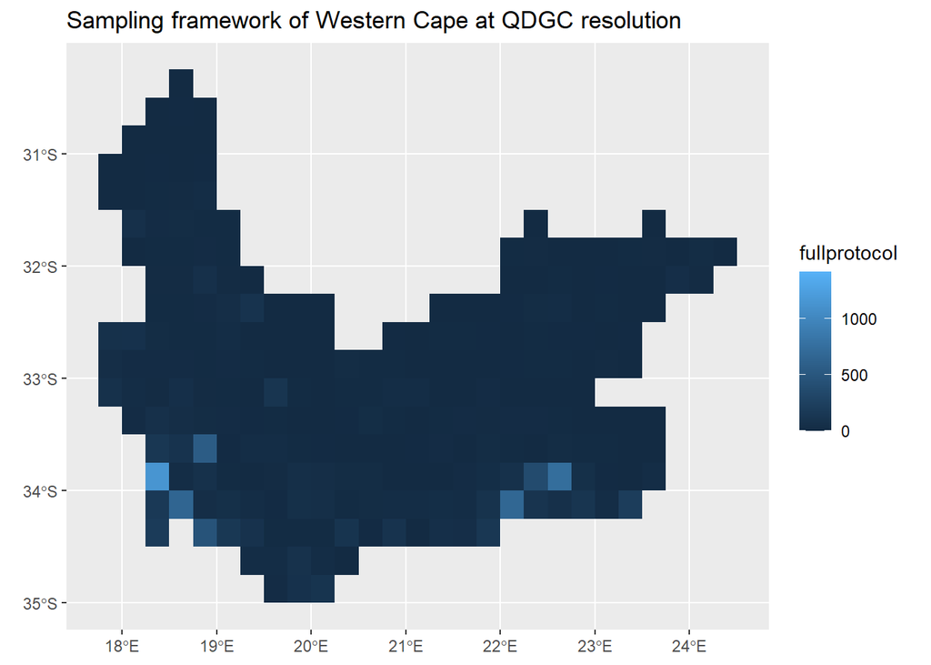

```r
# Remove geometry of sampling framework
WCSFDF<-sf::st_drop_geometry(WCSF)

# Add qdgc geometry of sampling framework by taking an inner join
WCSFQDGC_sf <- QDGC_sf %>%
  inner_join(WCSFDF %>%
             group_by(qdgccode) %>%
            summarise_at(vars('2008':'2024', 'fullprotocol'), sum, na.rm = TRUE),
             by = join_by(qdgc==qdgccode)) %>%
  st_sf(sf_column_name = "geom")

# Visualise spatial distribution of sampling framework
QDGC_sf %>%
 inner_join(WCSFDF,
            group_by(qdgccode) %>%
            summarise_at(vars('2008':'2024', 'fullprotocol'), sum, na.rm = TRUE), by = join_by(qdgc==qdgccode)) %>%
  ggplot() +
    geom_sf(aes(fill = fullprotocol), col = alpha("white", 0)) +
    ggtitle("Sampling framework of Western Cape at QDGC resolution")
```

Plot shows at a quarter degree resolution the number of full protocol surveys performed in the Western Cape

### SABAP2 data for Western Cape

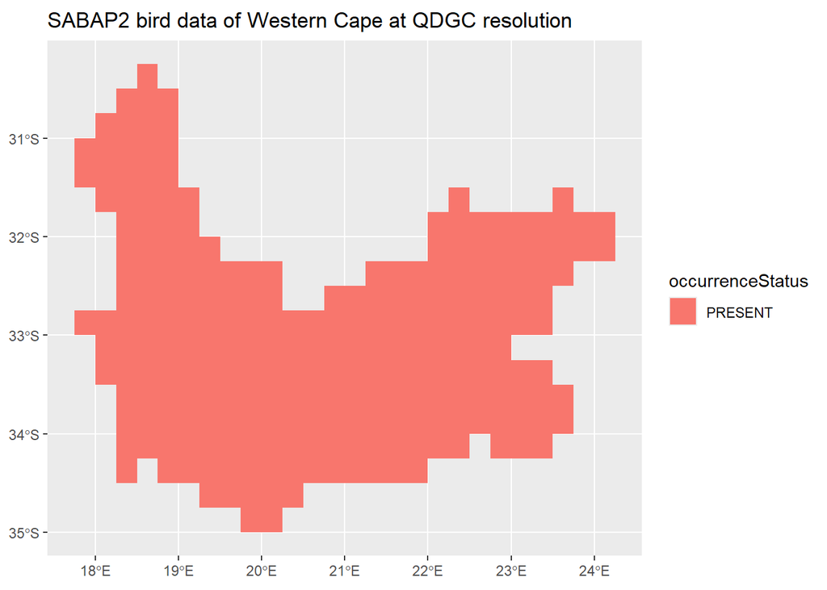

```r
# Add qdgc geometry by taking an inner join
SABAP2WCQDGC_sf <-  QDGC_sf %>%
  inner_join(SABAP2WC, by = join_by(qdgc==qdgccode)) %>%
  st_sf(sf_column_name = "geom")

# Visualise spatial distribution of structured data
QDGC_sf %>%
  inner_join(SABAP2WC %>%
              filter(occurrenceStatus == "PRESENT") %>%
              distinct(occurrenceStatus, qdgccode),
            by = join_by(qdgc==qdgccode)) %>%
  ggplot() +
    geom_sf(aes(fill = occurrenceStatus), col = alpha("white", 0)) +
    ggtitle("SABAP2 bird data of Western Cape at QDGC resolution")
```

Plot shows the grid cells (at quarter degree grid cell resolution) in which birds have been recorded through SABAP2 in the Western Cape

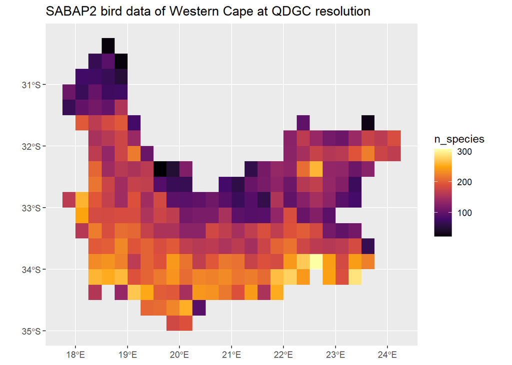

```r
# Visualise spatial distribution of stuctured data as number of species
QDGC_sf %>%
  inner_join(SABAP2WC %>%
              filter(occurrenceStatus == "PRESENT") %>%
              group_by(qdgccode) %>%
              summarise(n_species = n_distinct(species), .groups = "drop"),  by = join_by(qdgc==qdgccode)) %>%
  ggplot() +
    geom_sf(aes(fill = n_species), col = alpha("white", 0)) +
  scale_fill_viridis_c(option = "inferno") +
    ggtitle("SABAP2 bird data of Western Cape at QDGC resolution")
```

Plot shows the number of bird species recorded in grid cells (at quarter degree grid cell resolution) through SABAP2 in the Western Cape

### Bird occurrence cube for Western Cape

```r
# Add qdgc geometry by taking an inner join
birdcubeWCYearQDGC_sf <- QDGC_sf %>%
  inner_join(birdcubeWCYearQDGC, by = join_by(qdgc==qdgccode)) %>%
  st_sf(sf_column_name = "geom")
```

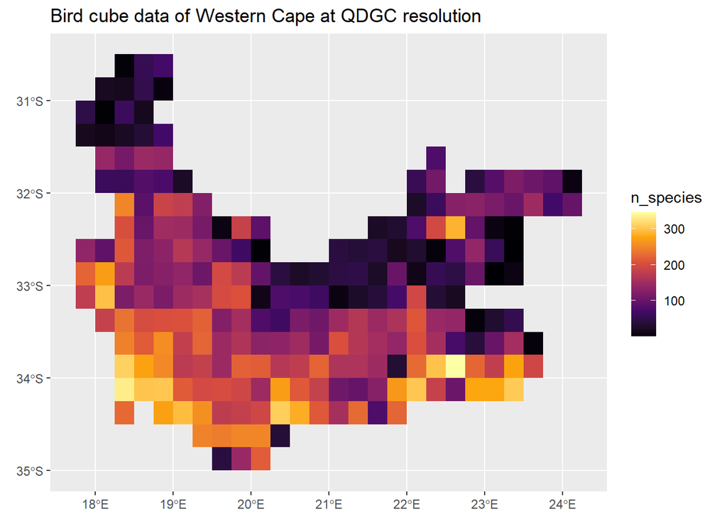

```r
# Visualise spatial distribution data cube as number of species
QDGC_sf %>%
  inner_join(birdcubeWCYearQDGC %>%
              group_by(qdgccode) %>%
              summarise(n_species = n_distinct(species), .groups = "drop"),
            by = join_by(qdgc==qdgccode)) %>%
  ggplot() +
    geom_sf(aes(fill = n_species), col = alpha("white", 0)) +
    scale_fill_viridis_c(option = "inferno") +
    ggtitle("Bird cube data of Western Cape at QDGC resolution")
```

Plot shows the number of species recorded in the unstructured data in the Western Cape at a QDGC resolution

## At pentad scale

### Sampling framework data for Western Cape

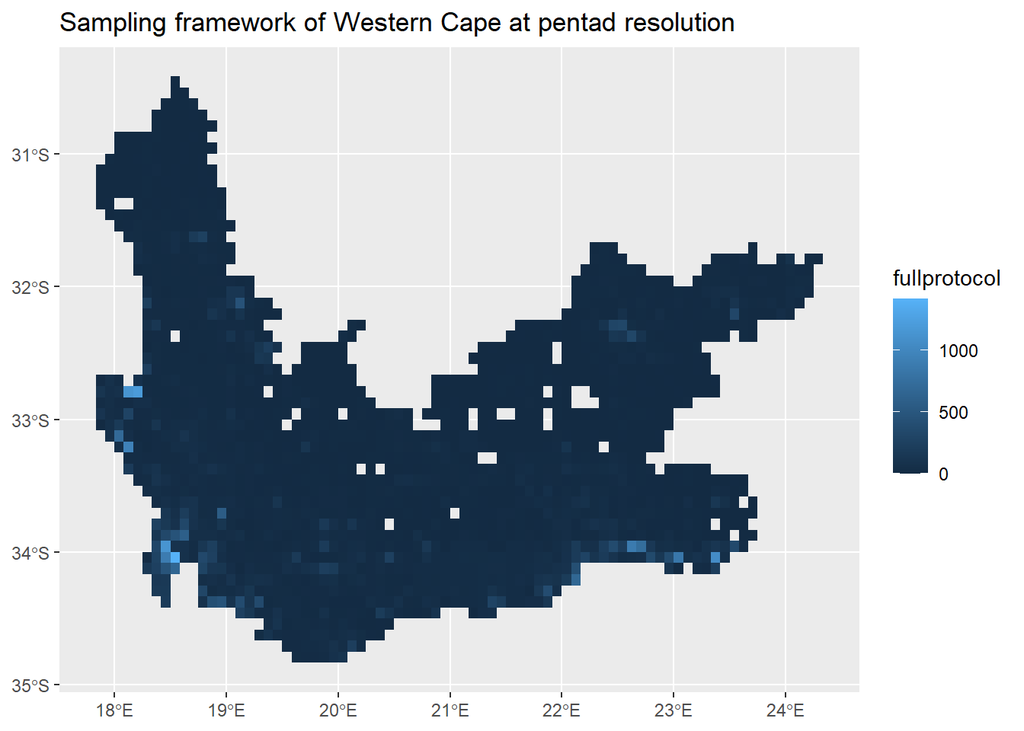

```r
# Visualise spatial distribution sampling framework
WCSF %>%
  ggplot() +
    geom_sf(aes(fill = fullprotocol),
            col = alpha("white", 0)) +
    ggtitle("Sampling framework of Western Cape at pentad resolution")
```

Plot shows at a pentad resolution the number of full protocol surveys performed in the Western Cape

### SABAP 2 data for Western Cape

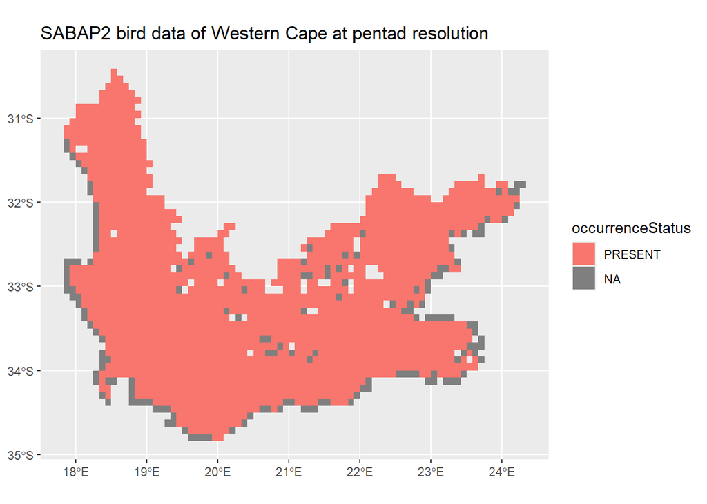

```r
# Add geometry of sampling framework by taking an inner join
SABAP2WCPentad_sf <- WCSF %>%
  inner_join(SABAP2WC, by = join_by(pentad)) %>%
  st_sf(sf_column_name = "geometry")

# Visualise spatial distribution of structured data
WCSF %>%
  left_join(SABAP2WC %>%
              filter(occurrenceStatus == "PRESENT") %>%
              distinct(occurrenceStatus, pentad),
            by = join_by(pentad)) %>%
  ggplot() +
    geom_sf(aes(fill = occurrenceStatus), col = alpha("white", 0)) +
    ggtitle("SABAP2 bird data of Western Cape at pentad resolution")
```

Plot shows the grid cells (at pentad resolution) in which birds have been recorded through SABAP2 in the Western Cape. Seems to be a spatial missmatch between data obtained from GBIF, and that obtained from SABAP2 website.

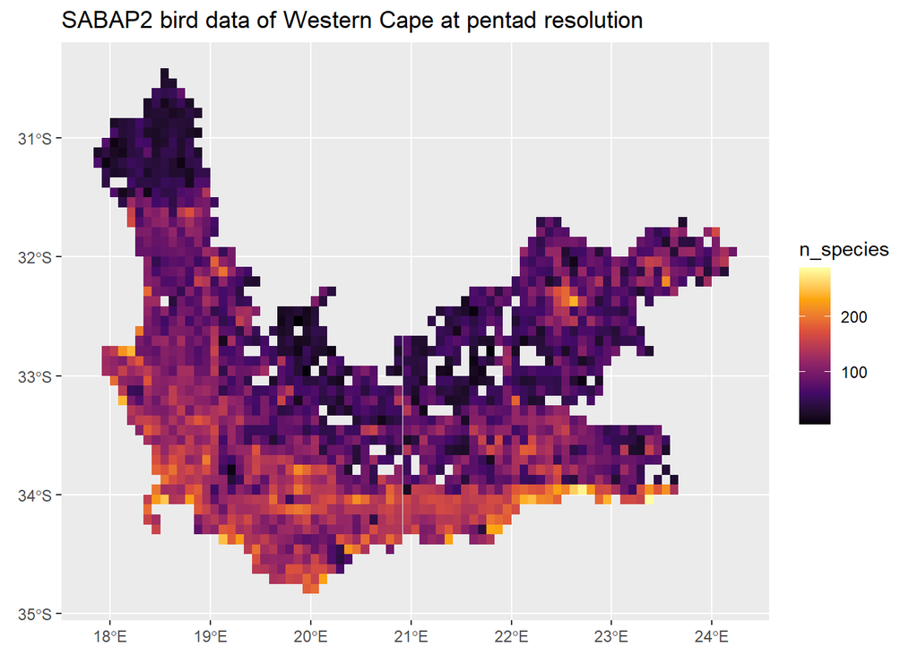

```r
# Visualise spatial distribution of structured data as number of species
WCSF %>%
  inner_join(SABAP2WC %>%
              filter(occurrenceStatus == "PRESENT") %>%
              group_by(pentad) %>%
              summarise(n_species = n_distinct(species), .groups = "drop"),  by = join_by(pentad)) %>%
  ggplot() +
    geom_sf(aes(fill = n_species), col = alpha("white", 0)) +
  scale_fill_viridis_c(option = "inferno") +
    ggtitle("SABAP2 bird data of Western Cape at pentad resolution")
```

Plot shows the number of bird species recorded in grid cells (at pentad resolution) through SABAP2 in the Western Cape

### Bird occurrence cube for Western Cape

```r
# Add geometry of sampling framework by taking an inner join
birdcubeWCYearPentad_sf <- WCSF %>%
  inner_join(birdcubeWCYearPentad, by = join_by(pentad)) %>%
  st_sf(sf_column_name = "geometry")
```

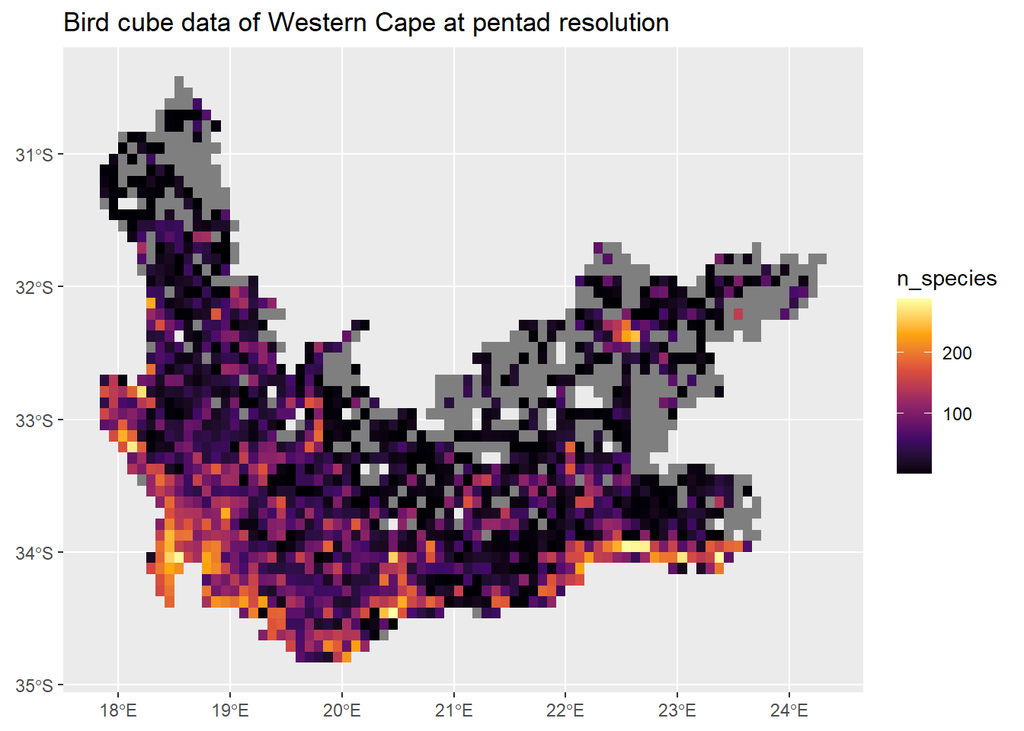

```r
# Visualise spatial distribution data cube as number of species
WCSF %>%
  left_join(birdcubeWCYearPentad %>%
              group_by(pentad) %>%
              summarise(n_species = n_distinct(species), .groups = "drop"),
            by = join_by(pentad)) %>%
  ggplot() +
    geom_sf(aes(fill = n_species), col = alpha("white", 0)) +
    scale_fill_viridis_c(option = "inferno") +
    ggtitle("Bird cube data of Western Cape at pentad resolution")
```

Plot shows the number of bird species recorded in grid cells (at pentad resolution) through unstructured sampling in the Western Cape

# Write out data

We write out the data for exploration and analysis.

```r
out_path <- here::here("data", "interim")
dir.create(out_path, showWarnings = FALSE, recursive = TRUE)

# Structured data at QDGC scale
write_sf(SABAP2WCQDGC_sf,
         file.path(out_path, "SABAP2_QDGC_WC_data.gpkg"))
write_sf(WCSFQDGC_sf,
         file.path(out_path, "sampling_framework_SABAP2_QDGC_WC.gpkg"))

# Structured data at pentad scale
write_sf(SABAP2WCPentad_sf,
         file.path(out_path, "SABAP2_Pentad_WC_data.gpkg"))
write_sf(WCSF,
         file.path(out_path, "sampling_framework_SABAP2_pentad_WC.gpkg"))

# Unstructured data at QDGC scale
write_sf(birdcubeWCYearQDGC_sf,
         file.path(out_path, "birdcube_QDGC_year_WC.gpkg"))

# Unstructured data at pentad scale
write_sf(birdcubeWCYearPentad_sf,
         file.path(out_path, "birdcube_Pentad_year_WC.gpkg"))
```